# tidyr

Etienne Low-Décarie

### Long vs wide data

Wide

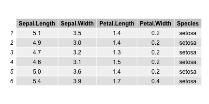

Long

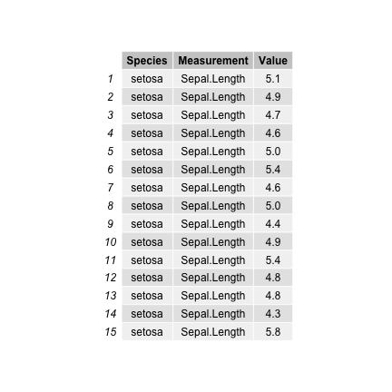

### Tidy vs untidy data

Tidy data

1. Each variable forms a column.
2. Each observation forms a row.
3. Each type of observational unit forms a table.

Messy data

- Anything else

[Wickham, H. (2014). Tidy Data. J. Stat. Softw., 59, 1–2.](http://www.jstatsoft.org/article/view/v059i10/v59i10.pdf)

### History

- `reshape` and `reshape2`
  - melt and cast
  - aggregate: summary calculations
- `tidyr`
  - only data frames
  - simple unique use verbs
  - no summarising/aggregation

### Going from wide to long

`gather`

```r
long_data<-gather(wide_data,
                  key,
                  value,
                  selected_columns)
```

`melt` in `reshape`(`2`)

### Ways to select columns

- Use bare variable names.

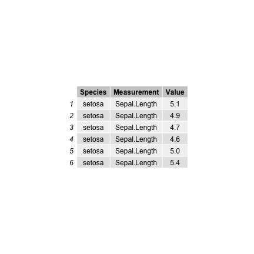

```r
long_iris<-gather(iris,"Measurement",
                  "Value",
                  Sepal.Length,
                  Sepal.Width,
                  Petal.Length,
                  Petal.Width)

grid.table(head(long_iris))
```

### Ways to select columns

- Select all variables between `x` and `z` with `x:z`

```r
long_iris<-gather(iris,"Measurement",
                  "Value",
                  Sepal.Length:Petal.Width)
```

### Ways to select columns

- Exclude y with `-y`.

```r
long_iris<-gather(iris,"Measurement",
                  "Value",
                  -Species)
```

### Exercise 1

- basic challenge
  - make the `data(BCI)` long (`require(vegan)`)
  - make the data in `data(simesants)` long (`require(simesants)`)
- extra challenge:  
  use `gather` to produce a data.frame from an image file that can be plotted using ggplot
  - use the `.nc` of world sea temperature file in the `Data` folder

### Going from long to wide

`spread`

```r
wide_data <- spread(long_data,
                    key,
                    value)
```

(`d`/`a`)cast in `reshape`(`2`)

### Going from long to wide

```r
wide_iris <- spread(long_iris,
                    Species,
                    Value)
```

### Going from long to wide

Each case must have a label!

```r
iris$Specimen <- rep(1:50,3) #Assumes specimen 1 of setosa
                            #matches specimen 1 of versicolor

long_iris<-gather(iris,"Measurement",
                  "Value",
                  Sepal.Length:Petal.Width)

wide_iris <- spread(long_iris,
                    Species,
                    Value)

wide_iris
```

```
    Specimen  Measurement setosa versicolor virginica
1          1 Sepal.Length    5.1        7.0       6.3
2          1  Sepal.Width    3.5        3.2       3.3
3          1 Petal.Length    1.4        4.7       6.0
4          1  Petal.Width    0.2        1.4       2.5
5          2 Sepal.Length    4.9        6.4       5.8
6          2  Sepal.Width    3.0        3.2       2.7
7          2 Petal.Length    1.4        4.5       5.1
8          2  Petal.Width    0.2        1.5       1.9
9          3 Sepal.Length    4.7        6.9       7.1
10         3  Sepal.Width    3.2        3.1       3.0
11         3 Petal.Length    1.3        4.9       5.9
12         3  Petal.Width    0.2        1.5       2.1
13         4 Sepal.Length    4.6        5.5       6.3
14         4  Sepal.Width    3.1        2.3       2.9
```

[output cut: 186 more lines]

### Exercise 2

- in `data(barley)` from `require(lattice)`  
  calculate the difference between `variety` *Manchuria* and *Velvet* for each site using `spread`

### Exercise 2

```r
barley_wide <- spread(barley,
                    variety,
                    yield)
```

### Going long for faceting by variable

Excellent for exploratory analysis

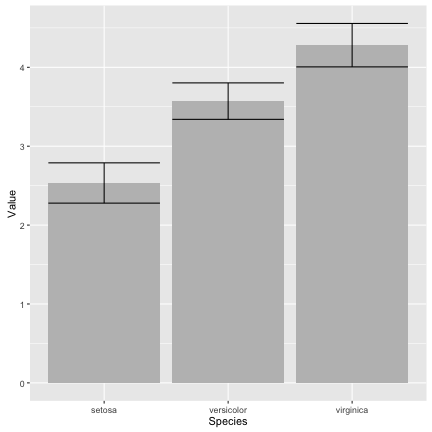

```r
p <- ggplot(data=long_iris,
            aes(x=Species,
           y=Value))+
           geom_bar(stat="summary",
           fun.y="mean",
           fill=I("grey"))+
  stat_summary(fun.data = "mean_cl_boot", geom="errorbar")
```

### Going long for faceting by variable

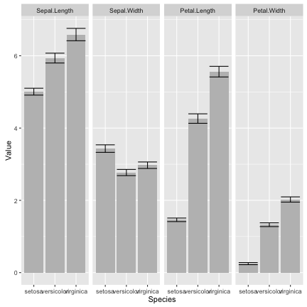

```r
print(p+facet_grid(.~Measurement))
```

### Going long for faceting by variable

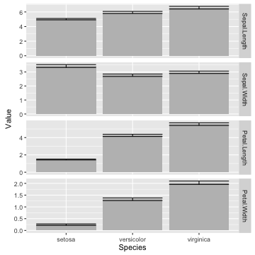

```r
print(p+facet_grid(Measurement~., scale="free"))
```

### Exercise 3

-using `gather` and `facets`

- plot a histogram of each of the variables in `USArrests`
- plot the time series for each of the variables in the `airquality` dataset

### Exercise 3

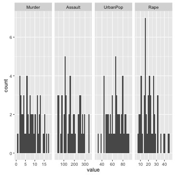

```r
USArrests_long <- gather(USArrests,
                         crime_var,
                         value)
p <- qplot(data=USArrests_long,
           x=value)+
  facet_grid(.~crime_var, scale="free")
print(p)
```

### Seperate string variable

```r
seperated_iris <- separate(long_iris,
                      Measurement,
                      c("Organ", "Dimension"))
```

### Seperate string variable and spreading

```r
wide_iris <- spread(seperated_iris,
                    Dimension,
                    Value)
```

### Plot seperated iris

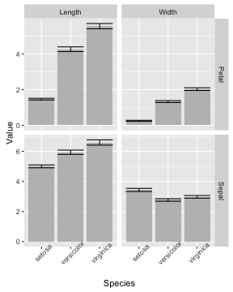

```r
p <- ggplot(data=seperated_iris,
           aes(x=Species,
           y=Value))+
           geom_bar(stat="summary",
           fun.y="mean",
           fill=I("grey"))+
  stat_summary(fun.data = "mean_cl_boot",
               geom="errorbar")+
  facet_grid(Organ~Dimension,
             scale="free")+
  theme(axis.text.x=element_text(angle=45))
```

### Exercise 4

Using facets, produce an exploratory plot of `Length, Body Width and Caudal` using the data from:  
Jacobson, B., Grant, J.W.A. & Peres-Neto, P.R., 2015. The interaction between the spatial distribution of resource patches and population density: consequences for intraspecific growth and morphology. Journal of Animal Ecology, 84(4), pp.934–942.  
[paper](http://onlinelibrary.wiley.com/doi/10.1111/1365-2656.12365/abstract;jsessionid=B13A863A84D13569CB0BB21F1FA10CD6.f03t01) [data](http://datadryad.org/resource/doi:10.5061/dryad.7nb71)

### Tidy default R outputs using broom

`tidy` in `broom` gets the coefficients of models into a data.frame

```r
require(broom)
tidy(lm(Petal.Width~Petal.Length, data=iris))
```

```
          term   estimate   std.error statistic      p.value
1  (Intercept) -0.3630755 0.039761990 -9.131221 4.699798e-16
2 Petal.Length  0.4157554 0.009582436 43.387237 4.675004e-86
```

### Tidy default R outputs

`glance` gets the overall summary statistics of models into a data.frame

```r
glance(lm(Petal.Width~Petal.Length, data=iris))
```

```
  r.squared adj.r.squared     sigma statistic      p.value df   logLik
1 0.9271098     0.9266173 0.2064843  1882.452 4.675004e-86  2 24.79555
        AIC       BIC deviance df.residual
1 -43.59109 -34.55919 6.310096         148
```

### Tidy default R outputs

`augment` in adds to the original data.frame the individual values from the model (eg. predicted)

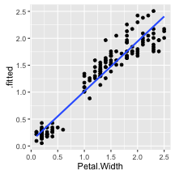

```r
require(broom)
augmented_iris<- augment(lm(Petal.Width~Petal.Length,
                            data=iris))
p <- qplot(data=augmented_iris,
      x=Petal.Width,
      y=.fitted)+
  geom_smooth(method="lm", se=F)
print(p)
```

### Feedback

[Feedback form](http://goo.gl/forms/3mH1UC0fH3) http://goo.gl/forms/3mH1UC0fH3